# Analysis of Suicide Rates Over Time

Many cultures have shamed the act of suicide and those that end their own lives. Whether or not that worked to deter the people of the time is another disscussion, but what we need to focus on now is how suicide rates have changed recently and how we can help those in need.

```python
import pandas as pd
import matplotlib.pyplot as plt
import matplotlib
```

This data was obtained from The World Health Organization

Link: www.who.int/data/gho/data/themes/mental-health/suicide-rates

```python
data = pd.read_csv('Age-standardized-suicide-rates.csv')
```

Just to help us understand this data, lets look at how Americas sucide rates have changed over time.

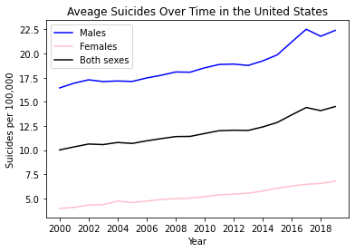

```python
years = [2000,2002,2004,2006,2008,2010,2012,2014,2016,2018]
M_plot_A = data.loc[(data['Dim1'] == 'Male')&(data['Location'] == 'United States of America')].plot('Period','FactValueNumeric',kind = 'line',c = 'b',label = 'Males')
F_plot_A = data.loc[(data['Dim1'] == 'Female')&(data['Location'] == 'United States of America')].plot('Period','FactValueNumeric',kind = 'line',ax = M_plot_A,c = 'pink',label = 'Females')
plot_A = data.loc[(data['Dim1'] == 'Both sexes')&(data['Location'] == 'United States of America')].plot('Period','FactValueNumeric',kind = 'line',ax = F_plot_A,c = 'black',label = 'Both sexes',xticks = years)
plt.title('Aveage Suicides Over Time in the United States')
plt.xlabel('Year')
plt.ylabel('Suicides per 100,000')
plt.show()
```

From here we can see that there has been a progressive rise in suicides over these recent decades. Now this data does not include any information on suicide rates in the year 2020, a landmark year that has changed many peoples lives worldwide. So there will be a large caveat to this analysis that all of this information if before the seismic events caused by the Covid-19 pandemic.

Trying to look at every countries suicide rates like we just did would be time consuming. Lets make a function so that we can get this information easier.

```python
def MakePlots(df,country):
    M_plot = df.loc[(df['Dim1'] == 'Male')&(df['Location'] == country)].plot('Period','FactValueNumeric',kind = 'line',c = 'b',label = 'Males')
    F_plot = df.loc[(df['Dim1'] == 'Female')&(df['Location'] == country)].plot('Period','FactValueNumeric',kind = 'line',ax = M_plot,c = 'pink',label = 'Females')
    A_plot = df.loc[(df['Dim1'] == 'Both sexes')&(df['Location'] == country)].plot('Period','FactValueNumeric',kind = 'line',ax = F_plot,c = 'black',label = 'Both sexes',xticks = years)
    plt.title('Aveage Suicides Over Time in ' + country)
    plt.xlabel('Year')
    plt.ylabel('Suicides per 100,000')
    plt.show()
```

Now to make sure it works, we'll try to recreate the American chart from before.

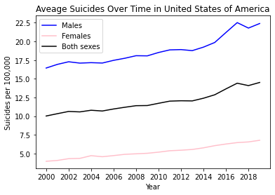

```python
MakePlots(data,'United States of America')
```

Alright now that we've done that lets try it in another country, say Rwanda.

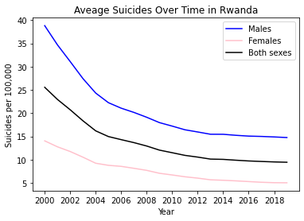

```python
MakePlots(data,'Rwanda')
```

Hmm...Rwanda showcases a massive downturn in suicides. We can't just look at each country and analyze every countries chart we need to look at the worldwide results.

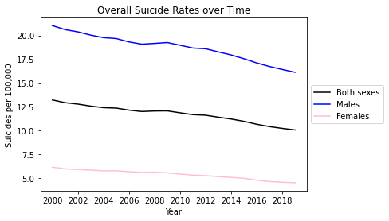

```python
Bdf = []
Mdf = []
Fdf = []
Periods = list(set(data['Period']))
for p in Periods:
    Brate = data.loc[(data['Period'] == p) & (data['Dim1'] == 'Both sexes')]['FactValueNumeric']
    Bdf.append(Brate.mean())
    Frate = data.loc[(data['Period'] == p) & (data['Dim1'] == 'Female')]['FactValueNumeric']
    Fdf.append(Frate.mean())
    Mrate = data.loc[(data['Period'] == p) & (data['Dim1'] == 'Male')]['FactValueNumeric']
    Mdf.append(Mrate.mean())
plot = plt.plot(Periods,Bdf,color = 'black',label = 'Both sexes')
plot = plt.plot(Periods,Mdf,color = 'blue',label='Males')
plot = plt.plot(Periods,Fdf,color = 'pink',label='Females')
plt.xticks(years)
plt.xlabel('Year')
plt.legend(loc='center right',bbox_to_anchor=(1.3, 0.5))
plt.title('Overall Suicide Rates over Time')
plt.ylabel('Suicides per 100,000')
plt.show()
```

Now this shows us that there has been a downturn in suicides over the years. This is a good sign that in fact we are improving in helping people in these situations not end their lives.

We can clealrly see in all of these graphs that suicide rates are higher among Males than Females, How much has that changed over time?

```python
print('Overall change in Female Suicides per 100,000 people: '+str(Fdf[19]-Fdf[0]))
print('Overall change in Male Suicides per 100,000 people: '+str(Mdf[19]-Mdf[0]))
```

```
Overall change in Female Suicides per 100,000 people: -1.6409836065573806
Overall change in Male Suicides per 100,000 people: -4.901803278688515
```

So suicide rates among Males has decreased more than Females in the last several years.